# Latent space DyNAMs with position-rate link

Authors

[Alberto Caimo](https://acaimo.github.io/)

[Isabella Gollini](https://igollini.github.io/)

This vignette shows the main functions of **ls.dynam** on simulated data. The model and the methods are described in Caimo and Gollini (2026), *Latent space dynamic network actor models with position-rate link*.

## Model specification

In a dynamic network actor model (DyNAM) each event is the outcome of two decisions: when an actor becomes active, and whom it selects. Actor $i$ becomes active with intensity
$$\lambda_i(t) = \exp\{\xi^\top s(i;t) + a_i\},$$
and selects receiver $j \neq i$ with probability proportional to $\exp\{\zeta^\top s(i,j;t) + u_i^\top v_j\}$, where $u_i$ and $v_j$ are latent sender and receiver positions. The choice model identifies the positions only up to transformations, but it identifies the *latent popularity* $\pi_i$, how much the average sender favours $i$ as a receiver, and the *excess self-affinity* $\rho_i$, the preference of $i$ for actors like itself beyond its popularity (`position_summaries()`). The position-rate link relates them to the activity effects:
$$a_i \sim N\{\mu_a + g_\pi(\pi_i) + g_\rho(\rho_i), \sigma_a^2\},$$
with natural cubic splines $g_\pi$ and $g_\rho$. Inference is modular: the positions are estimated from the choice of receivers alone, and the link is estimated given them.

## Simulated data

We simulate $M = 3{,}000$ events among $n = 40$ actors, with $D = 1$ latent dimension and activity associated with latent popularity only.

```r
library(ls.dynam)

n <- 40; D <- 1

f <- function(x) 1.5 * (plogis(3 * x) - 0.5) # a smooth curve

tr <- make_truth(n = n,
                 D = D,
                 link_fun = list(pop = f, rho = NULL),
                 link_var = c("pop", "rho"),
                 mean_u = 1, sigma_a = 0.5,
                 xi = c(rate_indeg = 0.1),
                 zeta = c(choice_recip = 0.5),
                 seed = 1)

ev <- simulate_lsdynam(tr$theta,
                       n = n,
                       M = 3000,
                       seed = 2)
head(ev, 3)
```

```
#>         time sender receiver
#> 1 0.03284149     31       30
#> 2 0.06311876     40       26
#> 3 0.08786836     22       30
```

## Estimation

`lsdynam_fit()` fits both stages. By default the statistics are the in-degree in the rate sub-process and reciprocity in the choice sub-process, and the link is the additive link in latent popularity and excess self-affinity. Here we use the Laplace approximation (`inference = "map"`), which takes seconds; the analysis in the paper uses posterior simulation (see below).

```r
fit <- lsdynam_fit(ev,
                   n = n,
                   D = D,
                   inference = "map",
                   n_starts = 3,
                   verbose = FALSE)

summary(fit)
```

```
#> Latent space DyNAM: n = 40 actors, M = 3000 events, D = 1
#> Inference: choice module laplace, rate module laplace
#> Link: pop + rho (spline); sigma_a = 0.457 (eb), sigma_kappa = 1.000 (fixed)
#>
#> Coefficients (posterior mean, sd and 95% credible interval):
#>                       mean     sd   lower upper
#> xi[rate_indeg]      0.1040 0.0201  0.0651 0.142
#> zeta[choice_recip]  0.4600 0.0396  0.3880 0.541
#> mu_a                0.0790 0.0982 -0.1130 0.270
#> kappa[pop_1]        0.1070 0.1570 -0.1890 0.410
#> kappa[pop_2]        0.4850 0.1110  0.2730 0.701
#> kappa[pop_3]        0.1710 0.1510 -0.1300 0.457
#> kappa[pop_4]        0.3900 0.0923  0.2080 0.570
#> kappa[rho_1]        0.0182 0.1510 -0.2780 0.296
#> kappa[rho_2]       -0.0304 0.0993 -0.2260 0.168
#> kappa[rho_3]        0.0285 0.1240 -0.2100 0.266
#> kappa[rho_4]       -0.0436 0.1060 -0.2520 0.158
#>
#> Contrasts of the components (level at the 90% minus level at the 10% quantile):
#>       x_10 x_90   mean  lower upper prob_positive
#> pop -1.180 1.30  1.750  1.260  2.20          1.00
#> rho -0.345 1.15 -0.192 -0.819  0.45          0.27
#> R2 of the link: 0.625
#>
#> Log Bayes factors:
#>           log_bf_savage_dickey log_bf_laplace
#> link                     13.80          13.10
#> pop | rho                19.30          18.80
#> rho | pop                -8.83          -8.75
```

The contrasts compare the level of each component at the 90% and 10% quantiles of its summary, and the log Bayes factors test the whole link and each component given the other. `plot()` shows the components of the link; the rug marks the actors’ values.

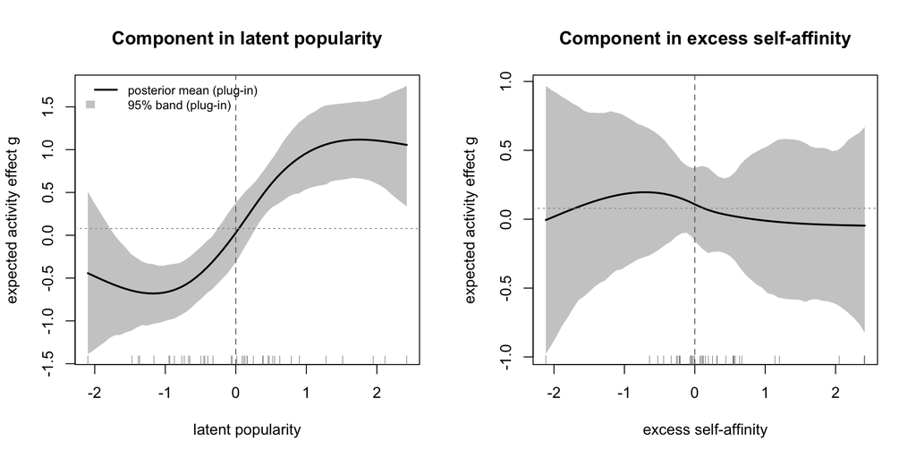

```r
plot(fit)
```

```r
ct <- link_contrast(fit, "pop")

round(c(estimate = ct$mean,
        lower = ct$ci[1],
        upper = ct$ci[2]), 2)
```

```
#> estimate    lower    upper
#>     1.75     1.26     2.20
```

```r
# excess self-affinity given popularity
link_evidence(fit, components = "rho")$log_bf10_laplace
```

```
#> [1] -8.749341
```

Links in other summaries can be compared on the same positions by their log marginal likelihoods; the difference between `"pop + rho"` and `"pop"` is the log Bayes factor for excess self-affinity given popularity.

```r
cmp <- link_comparison_table(fit,
                             list("pop + rho" = c("pop", "rho"),
                                  pop = "pop",
                                  rho = "rho", r = "r"))

cmp$table[, c("link", "K", "sigma_a", "log_ml_vs_M1", "R2")]
```

```
#>        link K   sigma_a log_ml_vs_M1          R2
#> 1 pop + rho 8 0.4572894    2.8926957  0.62465963
#> 2       pop 4 0.4337551   11.7227970  0.65843943
#> 3       rho 4 0.7395515   -6.2166191 -0.01230219
#> 4         r 4 0.6232275   -0.5346441  0.28485946
```

With one dimension the positions can be displayed. Filled points have positive self-affinity.

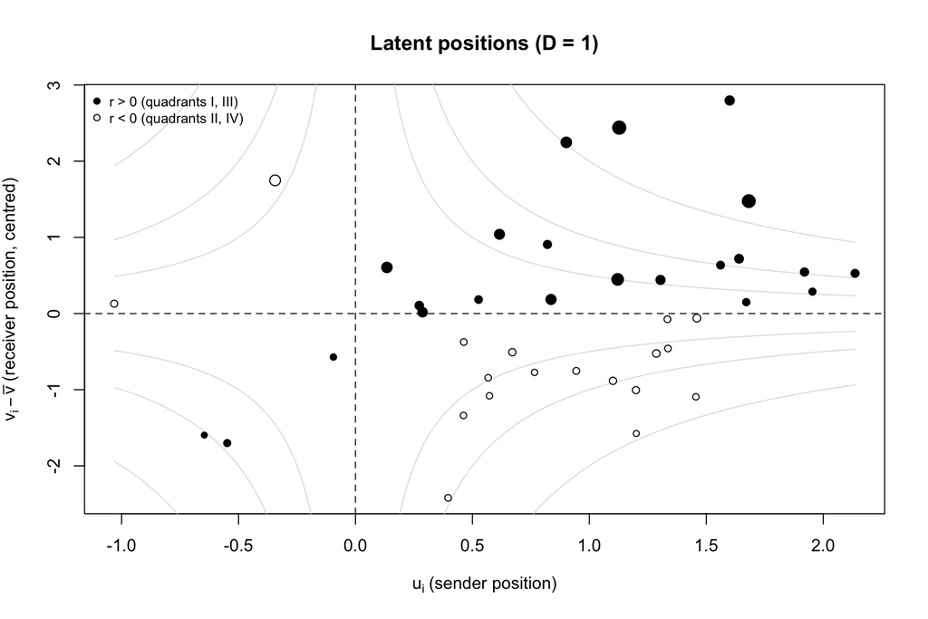

```r
plot_positions(fit, ellipses = FALSE)
```

## Prediction

The models are compared on held-out events: $\mathcal{M}_0$ has no latent positions, $\mathcal{M}_1$ has positions but no link, and $\mathcal{M}_2$ has both. The choice score compares $\mathcal{M}_1$ with $\mathcal{M}_0$, the rate score $\mathcal{M}_2$ with $\mathcal{M}_1$.

```r
m_tr <- 2400
train <- ev[seq_len(m_tr), ]

m0 <- lsdynam_fit(train,
                  n = n,
                  D = 0,
                  inference = "map",
                  verbose = FALSE)

m2 <- lsdynam_fit(train,
                  n = n,
                  D = 1,
                  inference = "map",
                  verbose = FALSE)

m1 <- lsdynam_fit(train,
                  n = n,
                  D = 1,
                  link = "none",
                  inference = "map",
                  choice = m2$choice,
                  verbose = FALSE)

sc <- lapply(list(M0 = m0,
                  M1 = m1,
                  M2 = m2),
             predictive_scores,
             events_full = ev,
             n = n,
             m_train = m_tr,
             n_draws = 100)

rbind("M1 - M0" = score_difference(sc$M1, sc$M0)[2, 2:4],
      "M2 - M1" = score_difference(sc$M2, sc$M1)[1, 2:4])
```

```
#>         units difference         se
#> M1 - M0   600 404.315987 24.8857022
#> M2 - M1    40   2.044529  0.8838632
```

The latent positions improve the prediction of the receivers considerably. The link improves the rate score only slightly, because the rate of an actor who has sent many events is determined by its own record: it describes how activity varies with position rather than improving the forecast of when actors send.

## Posterior simulation

The analysis of the paper simulates both modules with a Metropolis-adjusted Langevin algorithm (MALA), from many starting configurations of the choice module, and adds the cut posterior.

```r
fit <- lsdynam_fit(ev,
                   n = n,
                   D = D,
                   n_iter = 12000,
                   burn_in = 2000,
                   thin = 5,
                   n_starts = 10,
                   n_cut = 300)
```

```
#> Stage 1 (choice module, D = 1, mala)
#>   choice MAP: 8.1 s, convergence 0, 0 Hessian eigenvalue(s) floored
#>   starts: objective minus best = 1: 0.00, 2: 0.00, 3: 0.00, 4: 0.00, 5: 0.00, 6: 0.00, 7: 0.00, 8: 0.00, 9: 0.00, 10: 0.00, spectral: 0.00 | convergence codes 0 0 0 0 0 0 0 0 0 0 0
#>   MALA iteration 1000 / 12000 (eps = 0.728)
#>   MALA iteration 2000 / 12000 (eps = 0.758)
#>   MALA iteration 3000 / 12000 (eps = 0.758)
#>   MALA iteration 4000 / 12000 (eps = 0.758)
#>   MALA iteration 5000 / 12000 (eps = 0.758)
#>   MALA iteration 6000 / 12000 (eps = 0.758)
#>   MALA iteration 7000 / 12000 (eps = 0.758)
#>   MALA iteration 8000 / 12000 (eps = 0.758)
#>   MALA iteration 9000 / 12000 (eps = 0.758)
#>   MALA iteration 10000 / 12000 (eps = 0.758)
#>   MALA iteration 11000 / 12000 (eps = 0.758)
#>   MALA iteration 12000 / 12000 (eps = 0.758)
#>   acceptance 0.528, 34.0 s
#> Stage 2 (rate module, link = pop + rho)
#>   rate mode: sigma_a = 0.458 (eb), Newton iterations 1, converged TRUE
#>   acceptance 0.548, 1.9 s
```

```r
mcmc_diagnostics(fit)
```

```
#> Draws kept: choice 2000, rate 2000 | acceptance: choice 0.528, rate 0.548
#>   ESS zeta   min     771  median     771
#>   ESS r      min     593  median     775
#>   ESS pop    min     493  median     800
#>   ESS rho    min     560  median     798
#>   ESS xi     min    1244  median    1244
#>   ESS mu_a   min    1148  median    1148
#>   ESS kappa  min     979  median    1029
#>   ESS a      min     811  median    1163
```

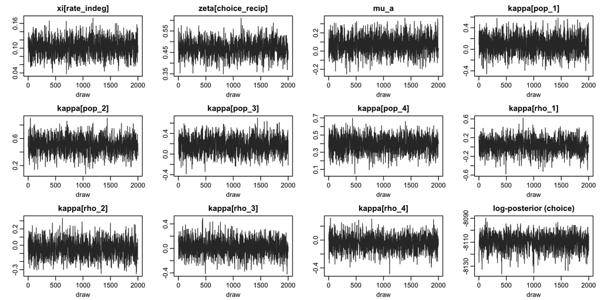

```r
plot_traces(fit)
```

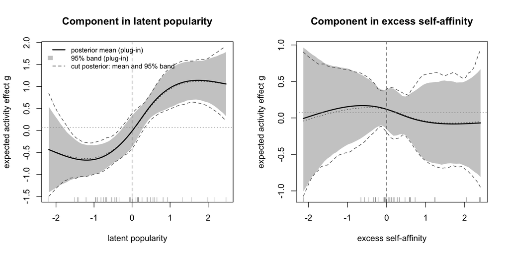

```r
plot(fit) # plug-in (shaded) and cut (dashed) posteriors
```

```r
link_evidence(fit,
              components = "rho",
              sigma_kappa_grid = c(0.1, 0.25, 0.5, 1, 2))
```

```
#> $log_bf10_sd
#> [1] -8.679039
#>
#> $log_bf10_laplace
#> [1] -8.732177
#>
#> $K
#> [1] 4
#>
#> $components
#> [1] "rho"
#>
#> $sigma2_kappa
#> [1] 1
#>
#> $sigma_kappa_method
#> [1] "fixed"
#>
#> $grid
#>  sigma_kappa=0.1 sigma_kappa=0.25  sigma_kappa=0.5    sigma_kappa=1
#>        -1.269153        -3.546291        -6.037299        -8.732177
#>    sigma_kappa=2
#>       -11.483835
```

```r
# reference distributions: no association, and popularity only
cal0 <- null_link_calibration(fit, n_rep = 10)
```

```
#>   replicate 1 / 10: R2 = 0.013, log BF10 = -11.35, given the rest: pop -5.81, rho -5.33
#>   replicate 2 / 10: R2 = -0.036, log BF10 = -12.26, given the rest: pop -5.60, rho -5.98
#>   replicate 3 / 10: R2 = -0.156, log BF10 = -13.24, given the rest: pop -6.52, rho -5.90
#>   replicate 4 / 10: R2 = 0.062, log BF10 = -10.98, given the rest: pop -3.74, rho -6.00
#>   replicate 5 / 10: R2 = -0.112, log BF10 = -13.48, given the rest: pop -6.77, rho -6.27
#>   replicate 6 / 10: R2 = -0.156, log BF10 = -13.49, given the rest: pop -6.77, rho -6.42
#>   replicate 7 / 10: R2 = 0.078, log BF10 = -10.25, given the rest: pop -2.91, rho -6.81
#>   replicate 8 / 10: R2 = 0.065, log BF10 = -10.23, given the rest: pop -2.58, rho -5.75
#>   replicate 9 / 10: R2 = -0.091, log BF10 = -12.50, given the rest: pop -6.55, rho -5.71
#>   replicate 10 / 10: R2 = 0.119, log BF10 = -9.76, given the rest: pop -3.49, rho -6.06
```

```r
cal1 <- null_link_calibration(fit, n_rep = 10, keep = "pop")
```

```
#>   replicate 1 / 10: R2 = 0.670, log BF10 = 19.05, given the rest: pop 26.94, rho -8.93
#>   replicate 2 / 10: R2 = 0.696, log BF10 = 22.63, given the rest: pop 30.14, rho -8.67
#>   replicate 3 / 10: R2 = 0.729, log BF10 = 28.81, given the rest: pop 34.37, rho -5.52
#>   replicate 4 / 10: R2 = 0.599, log BF10 = 9.52, given the rest: pop 17.15, rho -8.53
#>   replicate 5 / 10: R2 = 0.628, log BF10 = 12.50, given the rest: pop 20.75, rho -9.13
#>   replicate 6 / 10: R2 = 0.605, log BF10 = 11.65, given the rest: pop 16.71, rho -8.78
#>   replicate 7 / 10: R2 = 0.736, log BF10 = 28.70, given the rest: pop 31.35, rho -9.03
#>   replicate 8 / 10: R2 = 0.671, log BF10 = 16.46, given the rest: pop 23.37, rho -8.92
#>   replicate 9 / 10: R2 = 0.714, log BF10 = 24.91, given the rest: pop 28.65, rho -7.15
#>   replicate 10 / 10: R2 = 0.845, log BF10 = 64.29, given the rest: pop 56.00, rho -5.11
```

## Real data

The Radoslaw e-mail data are available from the KONECT collection (https://konect.cc/networks/radoslaw_email). The analysis of the paper used the second fifth of the observation period and the actors who both send and receive in it.

```r
ev <- read_konect_events("out.radoslaw_email_email")

ev <- prepare_events(ev)

ev <- select_time_window(ev,
                         start_frac = 0.2,
                         end_frac = 0.4)

fa <- filter_active_both(ev)

fit <- lsdynam_fit(fa$events_df,
                   n = fa$n,
                   D = 2,
                   n_iter = 12000,
                   burn_in = 2000,
                   thin = 5,
                   n_starts = 30,
                   n_cut = 300)
```